# Projeto com Feedback 2 02 - Machine Learning na Segurança do Trabalho Prevendo a Eficiência de Extintores de Incêndio

O teste hidrostático extintor é um procedimento estabelecido pelas normas da ABNT NBR 12962/2016, que determinam que todos os extintores devem ser testados a cada cinco anos, com a finalidade de identificar eventuais vazamentos, além de também verificar a resistência do material do extintor. Com isso, o teste hidrostático extintor pode ser realizado em baixa e alta pressão, de acordo com estas normas em questão. O procedimento é realizado por profissionais técnicos da área e com a utilização de aparelhos específicos e apropriados para o teste, visto que eles devem fornecer resultados com exatidão. Seria possível usar Machine Learning para prever o funcionamento de um extintor de incêndio com base em simulações feitas em computador e assim incluir uma camada adicional de segurança nas operações de uma empresa?

# Esse é o objetivo do Projeto com Feedback 2.

Usando dados reais disponíveis publicamente, seu trabalho é desenvolver um modelo de Machine Learning capaz de prever a eficiência de extintores de incêndio.

# Base dados

No link abaixo você encontra os dados necessários para o seu trabalho: https://www.muratkoklu.com/datasets/vtdhnd07.php

O conjunto de dados foi obtido como resultado dos testes de extinção de quatro chamas de combustíveis diferentes com um sistema de extinção de ondas sonoras. O sistema de extinção de incêndio por ondas sonoras consiste em 4 subwoofers com uma potência total de 4.000 Watts. Existem dois amplificadores que permitem que o som chegue a esses subwoofers como amplificado. A fonte de alimentação que alimenta o sistema e o circuito do filtro garantindo que as frequências de som sejam transmitidas adequadamente para o sistema está localizada dentro da unidade de controle. Enquanto o computador é usado como fonte de frequência, o anemômetro foi usado para medir o fluxo de ar resultante das ondas sonoras durante a fase de extinção da chama e um decibelímetro para medir a intensidade do som. Um termômetro infravermelho foi utilizado para medir a temperatura da chama e da lata de combustível, e uma câmera é instalada para detectar o tempo de extinção da chama. Um total de 17.442 testes foram realizados com esta configuração experimental. Os experimentos foram planejados da seguinte forma:

# Problema négocio

Três diferentes combustíveis líquidos e combustível GLP foram usados para criar a chama. 5 tamanhos diferentes de latas de combustível líquido foram usados para atingir diferentes tamanhos de chamas. O ajuste de meio e cheio de gás foi usado para combustível GLP. Durante a realização de cada experimento, o recipiente de combustível, a 10 cm de distância, foi movido para frente até 190 cm, aumentando a distância em 10 cm a cada vez. Junto com o recipiente de combustível, o anemômetro e o decibelímetro foram movidos para frente nas mesmas dimensões. Experimentos de extinção de incêndio foram conduzidos com 54 ondas sonoras de frequências diferentes em cada distância e tamanho de chama.

# Objetivo

Ao longo dos experimentos de extinção de chama, os dados obtidos de cada dispositivo de medição foram registrados e um conjunto de dados foi criado. O conjunto de dados inclui as características do tamanho do recipiente de combustível representando o tamanho da chama, tipo de combustível, frequência, decibéis, distância,fluxo de ar e extinção da chama. Assim, 6 recursos de entrada e 1 recurso de saída serão usados no modelo que você vai construir.

A coluna de status (extinção de chama ou não extinção da chama) pode ser prevista usando os seis recursos de entrada no conjunto de dados.

Os recursos de status e combustível são categóricos, enquanto outros recursos são numéricos.

Seu trabalho é construir um modelo de Machine Learning capaz de prever, com base em novos dados, se a chama será extinta ou não ao usar um extintor de incêndio.

# Descrição projeto

Definição do projeto: Nesse projeto, serão abordados diversos tópicos fundamentais para a realização de uma análise de dados robusta e a construção de modelos de machine learning eficazes. A seguir, apresento os detalhes das etapas que serão desenvolvidas.

1. Limpeza dos dados: O primeiro passo é realizar a limpeza dos dados, que consiste em identificar e corrigir possíveis erros, valores ausentes ou inconsistentes no conjunto de dados. Essa etapa é crucial para garantir a qualidade dos resultados finais.
2. Verificação de outliers: Em seguida, faremos uma análise cuidadosa para identificar e lidar com possíveis outliers (valores discrepantes). A presença de outliers pode afetar significativamente os resultados dos modelos, por isso é importante tratá-los adequadamente.
3. Análise exploratória dos dados: Antes de construir os modelos de machine learning, realizaremos uma análise exploratória dos dados. Isso nos ajudará a compreender melhor as relações entre as variáveis, identificar padrões e insights relevantes para o projeto.
4. Construção dos modelos de machine learning: Essa é uma das etapas centrais do projeto, onde iremos implementar seis algoritmos de machine learning diferentes. Os modelos que serão construídos são: Naive Bayes, Regressão Logística, Random Forest, KNN (K-Nearest Neighbors), SVM (Support Vector Machine) e Decision Tree.
5. Comparação dos modelos: Após construir os modelos, realizaremos uma análise comparativa para determinar quais algoritmos apresentam o melhor desempenho em relação aos nossos critérios de avaliação. Essa avaliação nos permitirá selecionar os melhores modelos para prosseguir no projeto.
6. Definição do modelo final: Com base nos resultados da etapa anterior, escolheremos o modelo (ou modelos) que melhor se adequam ao problema em questão. A seleção do modelo final é crucial para garantir uma previsão precisa e confiável.
7. Fazer previsões com os dados treinados: Na última etapa do projeto, utilizaremos os dados previamente treinados pelo modelo selecionado para fazer previsões em novos conjuntos de dados. Essa fase é a aplicação prática dos resultados obtidos e demonstrará a eficácia do modelo escolhido.

Por meio deste projeto abrangente, esperamos alcançar uma análise de dados mais confiável e obter resultados precisos por meio dos modelos de machine learning desenvolvidos. O processo de limpeza, análise e seleção dos melhores algoritmos é fundamental para tomar decisões informadas e auxiliar em problemas complexos que envolvam análise e previsão de dados.

Instalçaão pacotes

```r
install.packages("pROC")
install.packages("randomForest")
install.packages("randomForestExplainer")
install.packages("rpart.plot")
```

Importando as bibliotecas

```r
# Importando bibliotecas
library(pROC)
library(dplyr)
library(ggplot2)
library(readxl)
library(corrplot)
library(caret)
library(e1071)
library(randomForest)
library(xgboost)
library(class)
library(rpart)
library(rpart.plot)
```

Base dados

```r
data <- read_excel("Acoustic_Extinguisher_Fire_Dataset.xlsx")
```

[output not shown]

| SIZE | FUEL | DISTANCE | DESIBEL | AIRFLOW | FREQUENCY | STATUS |
| --- | --- | --- | --- | --- | --- | --- |
| 1 | gasoline | 10 | 96 | 0.0 | 75 | 0 |
| 1 | gasoline | 10 | 96 | 0.0 | 72 | 1 |
| 1 | gasoline | 10 | 96 | 2.6 | 70 | 1 |
| 1 | gasoline | 10 | 96 | 3.2 | 68 | 1 |
| 1 | gasoline | 10 | 109 | 4.5 | 67 | 1 |
| 1 | gasoline | 10 | 109 | 7.8 | 66 | 1 |

| SIZE | FUEL | DISTANCE | DESIBEL | AIRFLOW | FREQUENCY | STATUS |
| --- | --- | --- | --- | --- | --- | --- |
| 7 | lpg | 190 | 87 | 2.5 | 6 | 0 |
| 7 | lpg | 190 | 86 | 2.2 | 5 | 0 |
| 7 | lpg | 190 | 84 | 2.0 | 4 | 0 |
| 7 | lpg | 190 | 80 | 1.5 | 3 | 0 |
| 7 | lpg | 190 | 76 | 0.4 | 2 | 0 |
| 7 | lpg | 190 | 72 | 0.0 | 1 | 0 |

```r
# Linhas e colunas
dim(data)
```

```
[1] 17442     7
```

```r
# Linhas
nrow(data)
```

```
[1] 17442
```

```r
str(data)
```

```
tibble [17,442 × 7] (S3: tbl_df/tbl/data.frame)
 $ SIZE     : num [1:17442] 1 1 1 1 1 1 1 1 1 1 ...
 $ FUEL     : chr [1:17442] "gasoline" "gasoline" "gasoline" "gasoline" ...
 $ DISTANCE : num [1:17442] 10 10 10 10 10 10 10 10 10 10 ...
 $ DESIBEL  : num [1:17442] 96 96 96 96 109 109 103 95 102 93 ...
 $ AIRFLOW  : num [1:17442] 0 0 2.6 3.2 4.5 7.8 9.7 12 13.3 15.4 ...
 $ FREQUENCY: num [1:17442] 75 72 70 68 67 66 65 60 55 52 ...
 $ STATUS   : num [1:17442] 0 1 1 1 1 1 1 1 1 1 ...
```

```r
summary(data)
```

```
      SIZE           FUEL              DISTANCE      DESIBEL          AIRFLOW
 Min.   :1.000   Length:17442       Min.   : 10   Min.   : 72.00   Min.   : 0.000
 1st Qu.:2.000   Class :character   1st Qu.: 50   1st Qu.: 90.00   1st Qu.: 3.200
 Median :3.000   Mode  :character   Median :100   Median : 95.00   Median : 5.800
 Mean   :3.412                      Mean   :100   Mean   : 96.38   Mean   : 6.976
 3rd Qu.:5.000                      3rd Qu.:150   3rd Qu.:104.00   3rd Qu.:11.200
 Max.   :7.000                      Max.   :190   Max.   :113.00   Max.   :17.000
   FREQUENCY         STATUS
 Min.   : 1.00   Min.   :0.0000
 1st Qu.:14.00   1st Qu.:0.0000
 Median :27.50   Median :0.0000
 Mean   :31.61   Mean   :0.4978
 3rd Qu.:47.00   3rd Qu.:1.0000
 Max.   :75.00   Max.   :1.0000
```

# Limpeza dados

```r
# Valores ausentes
sum(is.na(data))
```

```
[1] 0
```

| SIZE | FUEL | DISTANCE | DESIBEL | AIRFLOW | FREQUENCY | STATUS |
| --- | --- | --- | --- | --- | --- | --- |
| 1 | gasoline | 10 | 96 | 0.0 | 75 | 0 |
| 1 | gasoline | 10 | 96 | 0.0 | 72 | 1 |
| 1 | gasoline | 10 | 96 | 2.6 | 70 | 1 |
| 1 | gasoline | 10 | 96 | 3.2 | 68 | 1 |
| 1 | gasoline | 10 | 109 | 4.5 | 67 | 1 |
| 1 | gasoline | 10 | 109 | 7.8 | 66 | 1 |
| 1 | gasoline | 10 | 103 | 9.7 | 65 | 1 |
| 1 | gasoline | 10 | 95 | 12.0 | 60 | 1 |
| 1 | gasoline | 10 | 102 | 13.3 | 55 | 1 |
| 1 | gasoline | 10 | 93 | 15.4 | 52 | 1 |

[output cut: 990 more lines]

```r
# Remover duplicatas
sum(duplicated(data))
```

```
[1] 0
```

# Análise exploratória

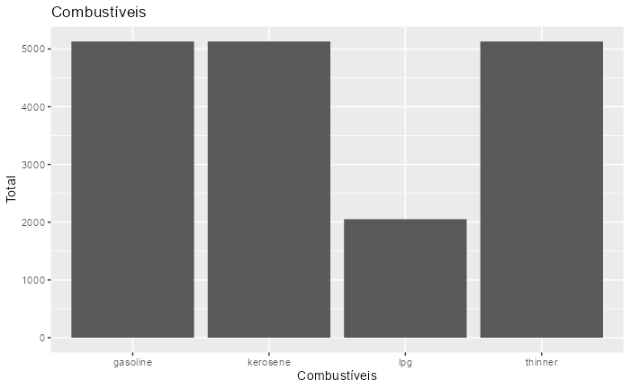

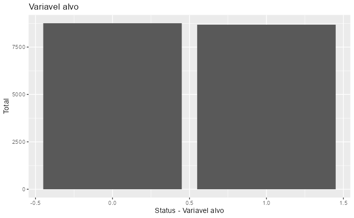

```r
# Gráfico Váriavel alvo
ggplot(data, aes(x = STATUS)) +
  xlab("Status - Variavel alvo") +
  ylab("Total") +
  ggtitle("Variavel alvo")+
  geom_bar()
```

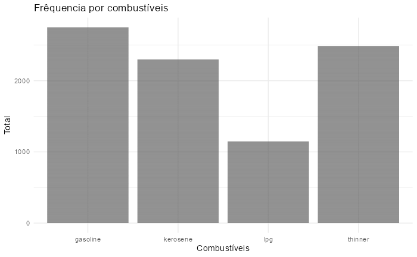

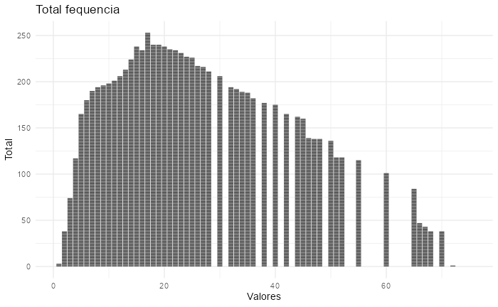

```r
# Gráfico de histrograma - Frêquencia por váriavel alvo
ggplot(data, aes(x = FREQUENCY, y = STATUS)) +
  geom_histogram(stat = "identity") +
  xlab("Valores") +
  ylab("Total") +
  ggtitle("Total fequencia") +
  theme_minimal()
```

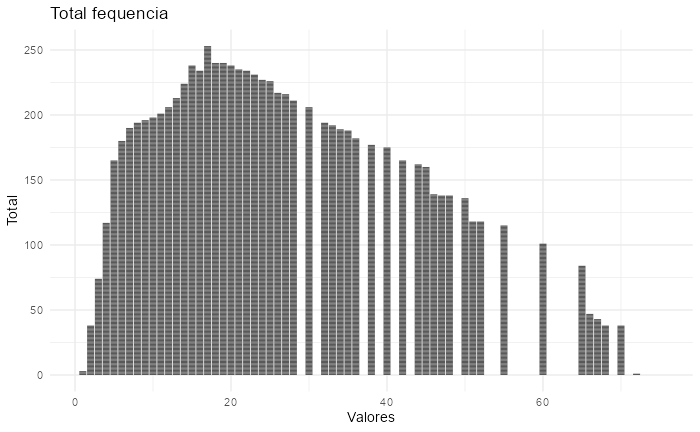

```r
# Gráfico de histrograma - Frêquencia por váriavel alvo
ggplot(data, aes(x = FREQUENCY, y = STATUS)) +
  geom_histogram(stat = "identity") +
  xlab("Valores") +
  ylab("Total") +
  ggtitle("Total fequencia") +
  theme_minimal()
```

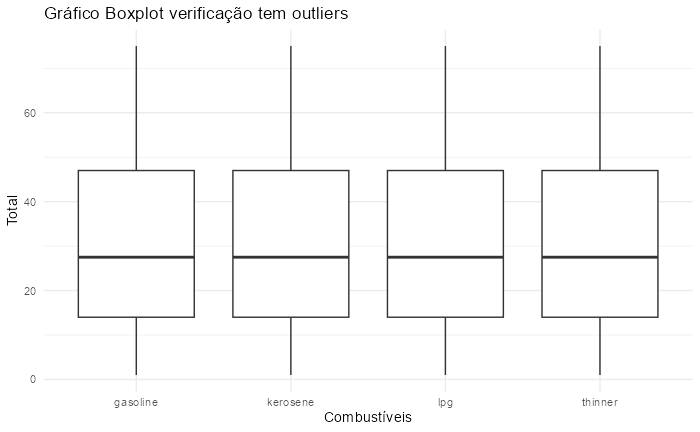

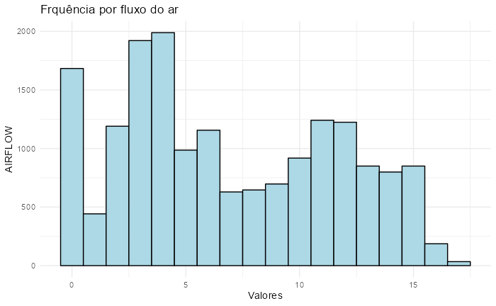

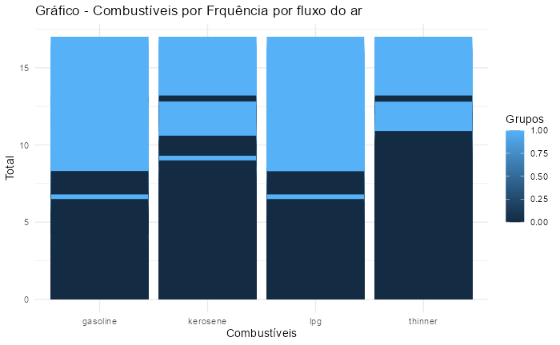

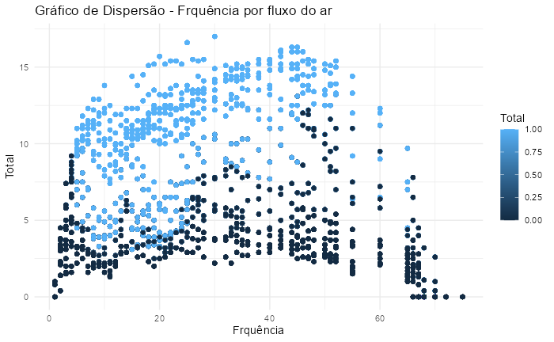

# Cálculo de correlação entre dados

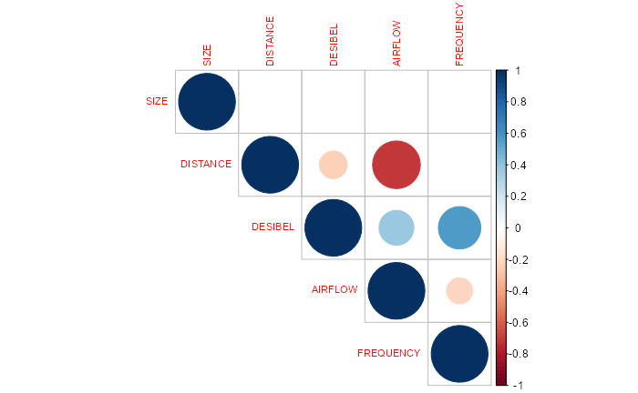

# Pré-processamento

```r
dim(test_y)
```

```
[1] 5232    7
```

# Modelo machine learning

```r
# Sumario dados
summary(modelo_naive_bayes)
```

```
          Length Class  Mode
apriori   2      table  numeric
tables    6      -none- list
levels    2      -none- character
isnumeric 6      -none- logical
call      4      -none- call
```

```r
model_naive_pred
```

[output not shown]

```r
acuracia_naive_bayes
```

```
[1] 0.8660168
```

```r
print(matriz_confusao_naive_bayes)
```

```
    Previsto
Real    0    1
   0 2361  267
   1  434 2170
```

# Modelo 2 - Random forest

```r
# Modelo Random Forest
modelo_rf <- randomForest(STATUS ~ ., data = train_x)
# Modelo Random Forest
modelo_rf <- randomForest(STATUS ~ ., data = train_x)
# Súmario modelo
summary(modelo_rf)
```

```
                Length Class  Mode
call                3  -none- call
type                1  -none- character
predicted       12210  -none- numeric
mse               500  -none- numeric
rsq               500  -none- numeric
oob.times       12210  -none- numeric
importance          6  -none- numeric
importanceSD        0  -none- NULL
localImportance     0  -none- NULL
proximity           0  -none- NULL
ntree               1  -none- numeric
mtry                1  -none- numeric
forest             11  -none- list
coefs               0  -none- NULL
y               12210  -none- numeric
test                0  -none- NULL
inbag               0  -none- NULL
terms               3  terms  call
```

# Gráfico Random Forest

```r
arvore
```

[output not shown]

```r
dados_treino_mat
```

[output not shown]

[output cut: 153 more lines]

[figure not shown]

```r
previsoes_rf
```

[output not shown]

[output cut: 487 more lines]

```r
print(paste("Acurácia Random Forest:", acuracia_rf))
```

```
[1] "Acurácia Random Forest: 0.497801987767584"
```

```r
# Matriz de confusão - Naive bayes
matriz_confusao_random_forest <- table(Real = test_y$STATUS, Previsto = previsoes_rf)
```

[output not shown]

## Modelo 3 - K-NN

# Encontrando o valor de K

```r
modelo_knn <- train(STATUS ~ .,
                    data = train_x,
                    method = "knn",
                    trControl = ctrl,
                    tuneLength = 10)
modelo_knn <- train(STATUS ~ .,
                    data = train_x,
                    method = "knn",
                    trControl = ctrl,
                    tuneLength = 10)
# Mostrar os resultados da busca pelo valor de k
print(modelo_knn)
```

```
k-Nearest Neighbors

12210 samples
    6 predictor

No pre-processing
Resampling: Cross-Validated (5 fold)
Summary of sample sizes: 9768, 9768, 9768, 9768, 9768
Resampling results across tuning parameters:

  k   RMSE       Rsquared   MAE
   5  0.2508282  0.7489480  0.1139395
   7  0.2487998  0.7525871  0.1170286
   9  0.2490287  0.7520511  0.1197931
  11  0.2496057  0.7508455  0.1222021
  13  0.2508492  0.7483765  0.1247428
  15  0.2524086  0.7452446  0.1267798
  17  0.2543140  0.7413880  0.1289594
  19  0.2559152  0.7381454  0.1307999
  21  0.2573959  0.7351197  0.1326063
  23  0.2585620  0.7326989  0.1340888

RMSE was used to select the optimal model using the smallest value.
The final value used for the model was k = 7.
```

```r
melhor_k
```

```
[1] 7
```

```r
# Calcular a acurácia para cada valor de k usando validação cruzada
for (i in seq_along(k_values)) {
  set.seed(42)
  ctrl <- trainControl(method = "cv", number = 5)
  modelo_knn <- train(STATUS ~ .,
                        data = train_x,
                        method = "knn",
                        trControl = ctrl,
                        tuneGrid = data.frame(k = k_values[i]))
  accuracies[[i]] <- modelo_knn$results$Accuracy
}
```

```r
dados_acuracia
```

```
Error: object 'dados_acuracia' not found
```

```r
# Criar o gráfico de linha
ggplot(dados_acuracia, aes(x = k, y = Accuracy)) +
  geom_line() +
  geom_point() +
  labs(x = "Valor de k", y = "Acurácia", title = "Acurácia em função do valor de k no modelo K-NN") +
  theme_minimal()
```

[output not shown]

```r
# Valor k
melhor_k
```

```
[1] 7
```

```r
# Súmario modelo
summary(modelo_knn)
```

```
            Length Class      Mode
learn       2      -none-     list
k           1      -none-     numeric
theDots     0      -none-     list
xNames      8      -none-     character
problemType 1      -none-     character
tuneValue   1      data.frame list
obsLevels   1      -none-     logical
param       0      -none-     list
```

```r
previsoes_knn
```

[output not shown]

[output cut: 119 more lines]

```r
print(paste("Acurácia K-NN:", acuracia_knn))
```

```
[1] "Acurácia K-NN: 0"
```

```r
# Matriz de confusão - knn
matriz_confusao_knn <- table(Real = test_y$STATUS, Previsto = previsoes_knn)
matriz_confusao_knn
```

[output not shown]